# Analyses for a restricted area

Andrew Edwards

This vignette shows how to extract and analyse the data for a restricted area (rather than the full coast). The example area is for predators of Haida Gwaii Herring, and we’ll stick with Yelloweye Rockfish as the example species (since those data are saved in the package).

Quick version – there is a wrapper function, `iphc_get_calc_plot_area(sp)` that does all the extraction, calculations, and plotting for a given species (see examples in analysis of HG herring predators vignette. This vignette shows the details to aid understanding. So for a quick look to see if the data look potentially useful, just do, for example, `iphc_get_calc_plot_area("bocaccio")`. If the resulting series looks useful then repeat this vignette for your species of interest to understand the results.

```r
library(gfiphc)
```

## Data for species of interest

Define common species name:

```r
sp <- "yelloweye rockfish"
sp_short_name <- "Yelloweye"  # short name for legends
```

As for the analysis of one species vignette, change the above names to your species of interest and have someone at PBS run the next chunk of code to extract data from the GFBio database.

```r
# This chunk will only work within PBS
cache_pbs_data_iphc(sp)
```

Once an external person has the `species-name.rds` file, the two lines in the next chunk can be appropriately commented/uncommented to load the data. For the vignette to always run we will stick with the Yelloweye Rockfish data.

```r
# Comment this out to analyse non-yelloweye data:
sp_set_counts <- yelloweye_rockfish

# Uncomment this to analyse non-yelloweye data:
# sp_set_counts <- readRDS(paste0(gsub(" ", "-", sp), ".rds"))
```

## Analyses for subset of stations

The area of interest is saved in `gfiphc` as `HG_herring_pred_area`:

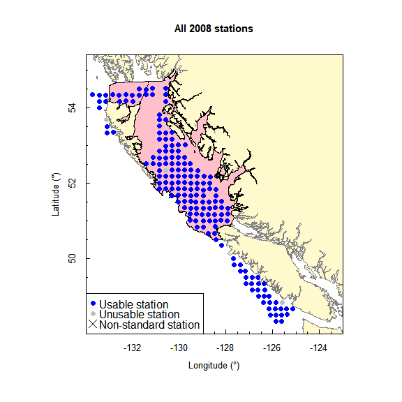

```r
plot_BC(main = "All 2008 stations")

PBSmapping::addPolys(HG_herring_pred_area,
                     col = "pink")

plot_iphc_map(sp_set_counts$set_counts,
              sp = NULL,
              years = 2008,
              lat_cut_off = NULL,
              add_to_existing = TRUE)
```

Create tibble of set counts with extra column `in_area`, which is `TRUE/FALSE` whether or not that set is within the area of interest:

```r
sp_set_counts_with_area <- add_in_area(sp_set_counts$set_counts,
                                       area = HG_herring_pred_area)
```

Each catch count now also has an `in_area` logical attribute:

```r
dplyr::select(sp_set_counts_with_area, year, station, lat, lon, E_it, C_it, usable,
              standard, in_area)
```

```
#> # A tibble: 4,745 × 9
#>     year station   lat   lon  E_it  C_it usable standard in_area
#>    <dbl> <chr>   <dbl> <dbl> <dbl> <dbl> <chr>  <fct>    <lgl>
#>  1  1995 10D      52.4 -129.  5.02  6.97 Y      Y        TRUE
#>  2  1995 10G      52.4 -130.  4.92  0    Y      Y        TRUE
#>  3  1995 10GC     52.3 -130   4.97  0    Y      Y        TRUE
#>  4  1995 10I      52.4 -130.  4.82  0    Y      Y        TRUE
#>  5  1995 10L      52.4 -131.  4.82  0    Y      Y        TRUE
#>  6  1995 10LC     52.3 -131.  4.97  0    Y      Y        TRUE
#>  7  1995 11E      52.6 -130   4.97  0    Y      Y        TRUE
#>  8  1995 11H      52.6 -130.  4.97  0    Y      Y        TRUE
#>  9  1995 11HC     52.7 -131.  4.97  0    Y      Y        TRUE
#> 10  1995 11J      52.6 -131.  4.92  0    Y      Y        TRUE
#> # … with 4,735 more rows
```

Colour code on map:

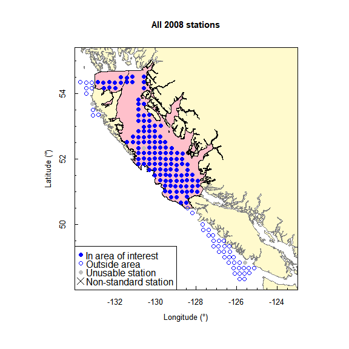

```r
plot_BC(main = "All 2008 stations")

PBSmapping::addPolys(HG_herring_pred_area,
                     col = "pink")

plot_iphc_map(sp_set_counts_with_area,
              sp = NULL,
              years = 2008,
              lat_cut_off = NULL,
              add_to_existing = TRUE,
              indicate_in_area = TRUE)
```

2022 (and 2018, 2020-2021) had expanded (non-standard) stations, which are shown as crosses:

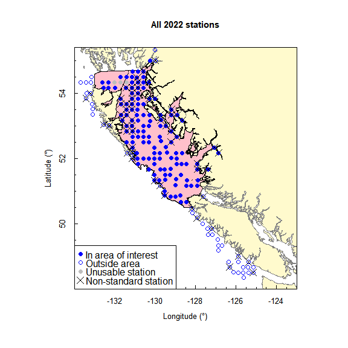

```r
plot_BC(main = "All 2022 stations")

PBSmapping::addPolys(HG_herring_pred_area,
                     col = "pink")

plot_iphc_map(sp_set_counts_with_area,
              sp = NULL,
              years = 2022,
              lat_cut_off = NULL,
              add_to_existing = TRUE,
              indicate_in_area = TRUE)
```

Make a movie to check each year:

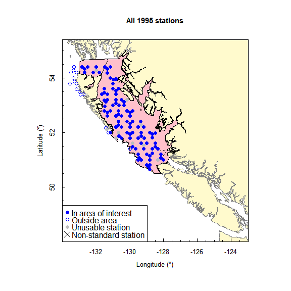

.

As for `data_for_one_species` vignette, the movie is saved and the code is given here but not run:

````r
# ```{r, animation.hook = 'gifski', interval = 1.5, fig.height = 6, results = FALSE}
for(i in unique(sp_set_counts_with_area$year)){
  plot_BC(main = paste0("All ", i, " stations"))

  PBSmapping::addPolys(HG_herring_pred_area,
                       col = "pink")

  plot_iphc_map(sp_set_counts_with_area,
                sp = NULL,
                years = i,
                lat_cut_off = NULL,
                add_to_existing = TRUE,
                indicate_in_area = TRUE)
}
````

## Calculate longest time series possible for the area of interest

In Appendix G of the synopsis report we described analyses to calculate as long a time series as possible by combining data from years when only the first 20 hooks were enumerated for each skate (Series A) and from years when all hooks could be enumerated from each skate (Series B); there are overlapping years when all hooks were enumerated and the data are available at the hook-by-hook level. The resulting Series AB applied only to the area north of WCVI, but was tested to see if it was representative of the whole coast.

For stations restricted to the area of interest, here we define Series E to be based on the first 20 hooks from each skate, and Series F to be based on all hooks from each skate. We do a similar analysis as described in the synopsis report to generate the longer Series EF (or just one of Series E and F if there are insufficient data). It is up to the user to generate maps (or movie) of their area of interest to confirm that it makes sense to use all stations with the area. For example, considering an area that reaches further down the west coast of Vancouver Island would not be appropriate since it was not surveyed in some years (Table G.2 of synopsis report).

The calculations are as follows, yielding figure with four plots similar to Figures G.1 and G.2 of the synopsis report (that were for Series A and B):

```r
ser_E_and_F <- calc_iphc_ser_E_and_F(sp_set_counts_with_area)
ser_E_and_F
```

```
#> $ser_E
#> # A tibble: 26 × 8
#>     year  Sets num_pos20 I_t20SampleMean I_t20BootMean I_t20Bo…¹ I_t20…² I_t20…³
#>    <dbl> <int>     <int>           <dbl>         <dbl>     <dbl>   <dbl>   <dbl>
#>  1  1997   103        29           1.86          1.86      1.14     3.05   0.246
#>  2  1998   118        40           1.81          1.81      1.16     3.12   0.253
#>  3  1999   124        46           1.60          1.59      1.05     2.44   0.214
#>  4  2000   119        41           1.64          1.64      1.09     2.42   0.200
#>  5  2001   125        36           1.55          1.56      1.03     2.37   0.212
#>  6  2002   126        31           0.872         0.874     0.553    1.51   0.254
#>  7  2003   125        41           0.994         0.998     0.641    1.65   0.241
#>  8  2004   124        37           1.29          1.30      0.850    1.97   0.211
#>  9  2005   126        38           1.15          1.15      0.761    1.79   0.219
#> 10  2006   126        28           1.15          1.15      0.711    1.82   0.235
#> # … with 16 more rows, and abbreviated variable names ¹I_t20BootLow,
#> #   ²I_t20BootHigh, ³I_t20BootCV
#>
#> $ser_F
#> # A tibble: 18 × 8
#>     year  Sets num_pos I_tSampleMean I_tBootMean I_tBootLow I_tBootHigh I_tBoo…¹
#>    <dbl> <int>   <int>         <dbl>       <dbl>      <dbl>       <dbl>    <dbl>
#>  1  1995    96      26         1.80        1.80       1.08         3.01    0.263
#>  2  1996   103      37         1.47        1.47       0.934        2.29    0.227
#>  3  2003   125      56         0.950       0.946      0.607        1.61    0.247
#>  4  2004   124      50         1.18        1.18       0.779        1.77    0.206
#>  5  2005   126      53         1.09        1.09       0.730        1.61    0.201
#>  6  2006   126      48         1.09        1.09       0.702        1.68    0.220
#>  7  2007   125      40         0.859       0.857      0.543        1.33    0.225
#>  8  2008   124      48         1.00        1.00       0.628        1.67    0.251
#>  9  2009   123      51         1.08        1.08       0.705        1.66    0.216
#> 10  2010   126      51         1.44        1.44       0.913        2.38    0.241
#> 11  2011   123      46         1.02        1.02       0.667        1.58    0.221
#> 12  2012   125      38         0.980       0.981      0.624        1.57    0.235
#> 13  2014   124      45         0.648       0.650      0.414        1.05    0.235
#> 14  2015   126      40         0.607       0.607      0.348        1.28    0.326
#> 15  2016   123      40         0.957       0.956      0.560        1.79    0.296
#> 16  2017   120      37         1.05        1.06       0.586        2.02    0.316
#> 17  2018   122      41         0.712       0.709      0.459        1.18    0.240
#> 18  2019   124      42         0.788       0.788      0.476        1.46    0.283
#> # … with abbreviated variable name ¹I_tBootCV
#>
#> attr(,"class")
#> [1] "IPHC_ser_E_and_F" "list"
```

Then to calculate the longest possible time series:

```r
series_longest <- calc_iphc_ser_EF(ser_E_and_F)
series_longest
```

```
#> $ser_longest
#> # A tibble: 28 × 8
#>     year  Sets num_pos20 I_t20SampleMean I_t20BootMean I_t20Bo…¹ I_t20…² I_t20…³
#>    <dbl> <int>     <int>           <dbl>         <dbl>     <dbl>   <dbl>   <dbl>
#>  1  1995    96        26           1.90          1.90      1.13     3.17   0.263
#>  2  1996   103        37           1.54          1.54      0.984    2.42   0.227
#>  3  1997   103        29           1.86          1.86      1.14     3.05   0.246
#>  4  1998   118        40           1.81          1.81      1.16     3.12   0.253
#>  5  1999   124        46           1.60          1.59      1.05     2.44   0.214
#>  6  2000   119        41           1.64          1.64      1.09     2.42   0.200
#>  7  2001   125        36           1.55          1.56      1.03     2.37   0.212
#>  8  2002   126        31           0.872         0.874     0.553    1.51   0.254
#>  9  2003   125        41           0.994         0.998     0.641    1.65   0.241
#> 10  2004   124        37           1.29          1.30      0.850    1.97   0.211
#> # … with 18 more rows, and abbreviated variable names ¹I_t20BootLow,
#> #   ²I_t20BootHigh, ³I_t20BootCV
#>
#> $test_EF
#> $test_EF$t_EF
#>
#>  Paired t-test
#>
#> data:  ser_E_scaled$I_t20BootMean and ser_F_scaled$I_tBootMean
#> t = 0.12691, df = 15, p-value = 0.9007
#> alternative hypothesis: true mean difference is not equal to 0
#> 95 percent confidence interval:
#>  -0.03684402  0.04150930
#> sample estimates:
#> mean difference
#>      0.00233264
#>
#>
#> $test_EF$G_E
#> [1] 0.994315
#>
#> $test_EF$G_F
#> [1] 0.9440221
#>
#> $test_EF$type
#> [1] "EF"
#>
#>
#> attr(,"class")
#> [1] "IPHC_ser_EF"
```

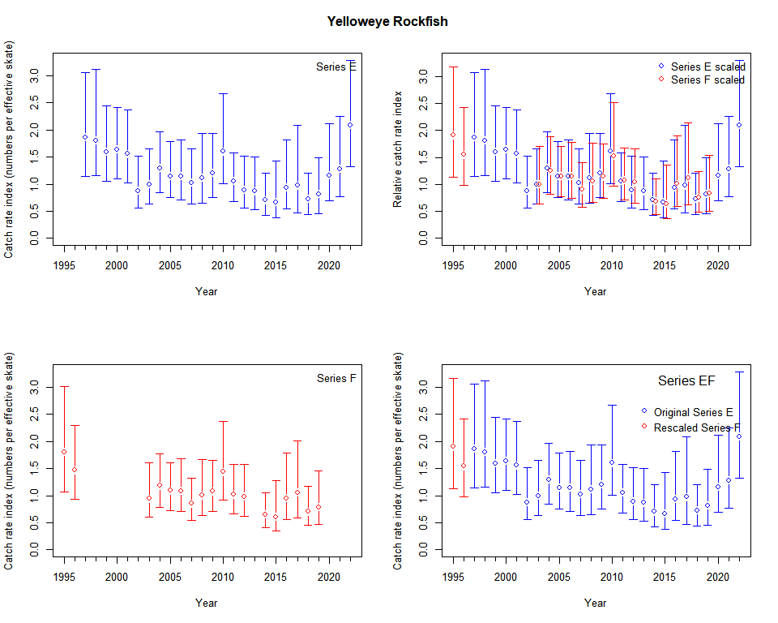

```r
plot_IPHC_ser_four_panels(ser_E_and_F,
                          series_longest,
                          sp = sp)
```

Comparing this figure in 2021 with an earlier version (before excluding non-standard stations), for 2020 (but not really 2018) excluding the non-standard stations increases the 2020 value somewhat. Interestingly, 2019 bootstrapped values change very slightly also, because of less random numbers now used for 2018 calculations (this motivates changing the default to 10,000 samples – see commented out text here for more info).

Recall there is a wrapper function, `iphc_get_calc_plot_area(sp)`, mentioned at the start of this vignette.

Note that the code may not yet fully account for all possibilities (for all areas and species) for the different Series, particularly for rarer species with, by definition, low count numbers. So do check that the output is sensible. The code may calculate a longest series, but it may not be ecologically useful.